# COVID-19 Reported Patient Impact and Hospital Capacity by State Timeseries (Dataset from HealthData.gov)

# Machine Learning Project

## Performed by R.Navarro, BSN, RN, CPAN, CCRN Alumnus

*NOTE: Codeblocks not shown.*

### Source (includes Data Dictionary):

https://healthdata.gov/Hospital/COVID-19-Reported-Patient-Impact-and-Hospital-Capa/g62h-syeh/about_data

### I - Get the Data

```
(81713, 135)
```

```
---
81713 INSTANCES (Rows)
135 FEATURES/ATTRIBUTES (Columns)
---
```

```
Index(['state', 'date', 'critical_staffing_shortage_today_yes',
       'critical_staffing_shortage_today_no',
       'critical_staffing_shortage_today_not_reported',
       'critical_staffing_shortage_anticipated_within_week_yes',
       'critical_staffing_shortage_anticipated_within_week_no',
       'critical_staffing_shortage_anticipated_within_week_not_reported',
       'hospital_onset_covid', 'hospital_onset_covid_coverage',
       ...
       'previous_day_admission_pediatric_covid_confirmed_5_11',
       'previous_day_admission_pediatric_covid_confirmed_5_11_coverage',
       'previous_day_admission_pediatric_covid_confirmed_unknown',
       'previous_day_admission_pediatric_covid_confirmed_unknown_coverage',
       'staffed_icu_pediatric_patients_confirmed_covid',
       'staffed_icu_pediatric_patients_confirmed_covid_coverage',
       'staffed_pediatric_icu_bed_occupancy',
       'staffed_pediatric_icu_bed_occupancy_coverage',
       'total_staffed_pediatric_icu_beds',
       'total_staffed_pediatric_icu_beds_coverage'],
      dtype='object', length=135)
```

```
---
Column names from dataset.
---
```

|  | critical_staffing_shortage_today_yes | critical_staffing_shortage_today_no | critical_staffing_shortage_today_not_reported | critical_staffing_shortage_anticipated_within_week_yes | critical_staffing_shortage_anticipated_within_week_no | critical_staffing_shortage_anticipated_within_week_not_reported | hospital_onset_covid | hospital_onset_covid_coverage | inpatient_beds | inpatient_beds_coverage | ... | previous_day_admission_pediatric_covid_confirmed_5_11 | previous_day_admission_pediatric_covid_confirmed_5_11_coverage | previous_day_admission_pediatric_covid_confirmed_unknown | previous_day_admission_pediatric_covid_confirmed_unknown_coverage | staffed_icu_pediatric_patients_confirmed_covid | staffed_icu_pediatric_patients_confirmed_covid_coverage | staffed_pediatric_icu_bed_occupancy | staffed_pediatric_icu_bed_occupancy_coverage | total_staffed_pediatric_icu_beds | total_staffed_pediatric_icu_beds_coverage |
| --- | --- | --- | --- | --- | --- | --- | --- | --- | --- | --- | --- | --- | --- | --- | --- | --- | --- | --- | --- | --- | --- |
| count | 81713.000000 | 81713.000000 | 81713.000000 | 81713.000000 | 81713.000000 | 81713.000000 | 80756.000000 | 81713.000000 | 81708.000000 | 81713.000000 | ... | 44677.000000 | 81713.000000 | 45417.000000 | 81713.000000 | 51564.000000 | 81713.000000 | 73410.000000 | 81713.000000 | 73397.000000 | 81713.000000 |
| mean | 7.856608 | 47.398945 | 47.450271 | 12.639837 | 62.446465 | 27.619522 | 20.026091 | 85.638319 | 13285.218718 | 101.101759 | ... | 0.523961 | 50.954793 | 0.585420 | 52.932557 | 2.612288 | 57.650239 | 158.189348 | 78.873974 | 237.000627 | 78.738242 |
| std | 14.923570 | 59.023908 | 69.327673 | 18.915257 | 59.395291 | 58.285291 | 48.785796 | 86.808464 | 14600.411077 | 90.828977 | ... | 1.361718 | 77.433429 | 4.138465 | 79.509095 | 5.797625 | 80.051161 | 268.134969 | 85.595748 | 404.702566 | 85.618299 |
| min | 0.000000 | 0.000000 | 0.000000 | 0.000000 | 0.000000 | 0.000000 | 0.000000 | 0.000000 | 0.000000 | 0.000000 | ... | 0.000000 | 0.000000 | -1.000000 | 0.000000 | 0.000000 | 0.000000 | 0.000000 | 0.000000 | 0.000000 | 0.000000 |
| 25% | 0.000000 | 3.000000 | 5.000000 | 1.000000 | 17.000000 | 3.000000 | 1.000000 | 27.000000 | 3100.000000 | 43.000000 | ... | 0.000000 | 0.000000 | 0.000000 | 0.000000 | 0.000000 | 0.000000 | 17.000000 | 15.000000 | 29.000000 | 15.000000 |
| 50% | 2.000000 | 24.000000 | 22.000000 | 6.000000 | 52.000000 | 10.000000 | 6.000000 | 61.000000 | 8833.000000 | 90.000000 | ... | 0.000000 | 13.000000 | 0.000000 | 13.000000 | 1.000000 | 26.000000 | 66.000000 | 59.000000 | 101.000000 | 59.000000 |
| 75% | 10.000000 | 78.000000 | 64.000000 | 18.000000 | 89.000000 | 29.000000 | 19.000000 | 116.000000 | 16895.000000 | 132.000000 | ... | 1.000000 | 87.000000 | 0.000000 | 93.000000 | 3.000000 | 95.000000 | 174.000000 | 112.000000 | 258.000000 | 112.000000 |
| max | 191.000000 | 494.000000 | 523.000000 | 204.000000 | 469.000000 | 523.000000 | 1334.000000 | 597.000000 | 108966.000000 | 598.000000 | ... | 101.000000 | 591.000000 | 155.000000 | 595.000000 | 346.000000 | 595.000000 | 2580.000000 | 597.000000 | 3917.000000 | 597.000000 |

8 rows × 133 columns

```
---
Summary statistics of numerical columns of dataset.
---
```

```
<class 'pandas.core.frame.DataFrame'>
RangeIndex: 81713 entries, 0 to 81712
Columns: 135 entries, state to total_staffed_pediatric_icu_beds_coverage
dtypes: float64(77), int64(56), object(2)
memory usage: 84.2+ MB
```

```
---
Summary of dataset which includes data types of columns.
---
```

```
state                                                         0
date                                                          0
critical_staffing_shortage_today_yes                          0
critical_staffing_shortage_today_no                           0
critical_staffing_shortage_today_not_reported                 0
                                                           ...
staffed_icu_pediatric_patients_confirmed_covid_coverage       0
staffed_pediatric_icu_bed_occupancy                        8303
staffed_pediatric_icu_bed_occupancy_coverage                  0
total_staffed_pediatric_icu_beds                           8316
total_staffed_pediatric_icu_beds_coverage                     0
Length: 135, dtype: int64
```

```
---
Numerous null values noted.
---
```

|  | state | date | critical_staffing_shortage_today_yes | critical_staffing_shortage_today_no | critical_staffing_shortage_today_not_reported | critical_staffing_shortage_anticipated_within_week_yes | critical_staffing_shortage_anticipated_within_week_no | critical_staffing_shortage_anticipated_within_week_not_reported | hospital_onset_covid | hospital_onset_covid_coverage | ... | previous_day_admission_pediatric_covid_confirmed_5_11 | previous_day_admission_pediatric_covid_confirmed_5_11_coverage | previous_day_admission_pediatric_covid_confirmed_unknown | previous_day_admission_pediatric_covid_confirmed_unknown_coverage | staffed_icu_pediatric_patients_confirmed_covid | staffed_icu_pediatric_patients_confirmed_covid_coverage | staffed_pediatric_icu_bed_occupancy | staffed_pediatric_icu_bed_occupancy_coverage | total_staffed_pediatric_icu_beds | total_staffed_pediatric_icu_beds_coverage |
| --- | --- | --- | --- | --- | --- | --- | --- | --- | --- | --- | --- | --- | --- | --- | --- | --- | --- | --- | --- | --- | --- |
| 0 | MA | 2021/06/15 | 6 | 72 | 1 | 6 | 72 | 1 | 4.0 | 78 | ... | NaN | 0 | NaN | 0 | NaN | 0 | NaN | 0 | NaN | 0 |
| 1 | WY | 2021/06/13 | 2 | 26 | 2 | 3 | 25 | 2 | 0.0 | 28 | ... | NaN | 0 | NaN | 0 | NaN | 0 | 0.0 | 8 | 0.0 | 8 |
| 2 | LA | 2021/06/06 | 41 | 176 | 6 | 41 | 176 | 6 | 2.0 | 217 | ... | NaN | 0 | NaN | 0 | NaN | 0 | 5.0 | 4 | 11.0 | 4 |
| 3 | RI | 2021/06/04 | 4 | 9 | 2 | 4 | 9 | 2 | 5.0 | 14 | ... | NaN | 0 | NaN | 0 | NaN | 0 | 78.0 | 14 | 96.0 | 14 |
| 4 | KS | 2021/06/03 | 13 | 133 | 4 | 15 | 131 | 4 | 1.0 | 147 | ... | NaN | 0 | NaN | 0 | NaN | 0 | 81.0 | 147 | 273.0 | 147 |
| 5 | ME | 2021/06/03 | 2 | 28 | 9 | 1 | 29 | 9 | 3.0 | 38 | ... | NaN | 0 | NaN | 0 | NaN | 0 | 23.0 | 30 | 24.0 | 30 |
| 6 | RI | 2021/06/02 | 4 | 10 | 1 | 4 | 10 | 1 | 5.0 | 14 | ... | NaN | 0 | NaN | 0 | NaN | 0 | 68.0 | 14 | 96.0 | 14 |
| 7 | ME | 2021/05/30 | 1 | 29 | 9 | 1 | 29 | 9 | 3.0 | 38 | ... | NaN | 0 | NaN | 0 | NaN | 0 | 22.0 | 30 | 22.0 | 30 |
| 8 | RI | 2021/05/30 | 3 | 11 | 1 | 4 | 10 | 1 | 5.0 | 14 | ... | NaN | 0 | NaN | 0 | NaN | 0 | 72.0 | 14 | 96.0 | 14 |
| 9 | MS | 2021/05/28 | 10 | 96 | 2 | 12 | 94 | 2 | 3.0 | 106 | ... | NaN | 0 | NaN | 0 | NaN | 0 | 86.0 | 106 | 177.0 | 106 |
| 10 | RI | 2021/05/28 | 4 | 9 | 2 | 4 | 9 | 2 | 5.0 | 14 | ... | NaN | 0 | NaN | 0 | NaN | 0 | 79.0 | 14 | 96.0 | 14 |
| 11 | RI | 2021/05/27 | 4 | 10 | 1 | 4 | 10 | 1 | 6.0 | 14 | ... | NaN | 0 | NaN | 0 | NaN | 0 | 80.0 | 14 | 96.0 | 14 |
| 12 | SD | 2021/05/26 | 0 | 62 | 3 | 1 | 61 | 3 | 5.0 | 62 | ... | NaN | 0 | NaN | 0 | NaN | 0 | 34.0 | 62 | 93.0 | 62 |
| 13 | RI | 2021/05/25 | 4 | 9 | 1 | 4 | 9 | 1 | 6.0 | 13 | ... | NaN | 0 | NaN | 0 | NaN | 0 | 76.0 | 13 | 95.0 | 13 |
| 14 | RI | 2021/05/24 | 4 | 9 | 1 | 4 | 9 | 1 | 6.0 | 13 | ... | NaN | 0 | NaN | 0 | NaN | 0 | 78.0 | 13 | 96.0 | 13 |
| 15 | ME | 2021/05/23 | 0 | 30 | 9 | 1 | 29 | 9 | 0.0 | 38 | ... | NaN | 0 | NaN | 0 | NaN | 0 | 27.0 | 30 | 27.0 | 30 |
| 16 | RI | 2021/05/23 | 4 | 10 | 1 | 4 | 10 | 1 | 19.0 | 14 | ... | NaN | 0 | NaN | 0 | NaN | 0 | 77.0 | 14 | 96.0 | 14 |
| 17 | ID | 2021/05/21 | 4 | 41 | 8 | 6 | 39 | 8 | 2.0 | 52 | ... | NaN | 0 | NaN | 0 | NaN | 0 | 88.0 | 32 | 229.0 | 32 |
| 18 | ND | 2021/05/20 | 12 | 38 | 1 | 11 | 39 | 1 | 19.0 | 50 | ... | NaN | 0 | NaN | 0 | NaN | 0 | 35.0 | 8 | 56.0 | 8 |
| 19 | RI | 2021/05/20 | 4 | 9 | 2 | 4 | 9 | 2 | 5.0 | 14 | ... | NaN | 0 | NaN | 0 | NaN | 0 | 76.0 | 14 | 96.0 | 14 |
| 20 | AK | 2021/05/19 | 1 | 23 | 0 | 2 | 22 | 0 | 0.0 | 24 | ... | NaN | 0 | NaN | 0 | NaN | 0 | 55.0 | 24 | 70.0 | 24 |
| 21 | NE | 2021/05/19 | 8 | 92 | 1 | 16 | 84 | 1 | 3.0 | 100 | ... | NaN | 0 | NaN | 0 | NaN | 0 | 22.0 | 14 | 32.0 | 14 |
| 22 | NE | 2021/05/18 | 7 | 92 | 1 | 15 | 84 | 1 | 2.0 | 99 | ... | NaN | 0 | NaN | 0 | NaN | 0 | 22.0 | 13 | 32.0 | 13 |
| 23 | RI | 2021/05/18 | 3 | 9 | 2 | 4 | 8 | 2 | 5.0 | 13 | ... | NaN | 0 | NaN | 0 | NaN | 0 | 72.0 | 13 | 96.0 | 13 |
| 24 | NE | 2021/05/16 | 8 | 92 | 1 | 15 | 85 | 1 | 0.0 | 100 | ... | NaN | 0 | NaN | 0 | NaN | 0 | 0.0 | 16 | 0.0 | 16 |

25 rows × 135 columns

```
---
First 25 rows from dataset.
---
```

```
---
Null values imputed to a value of 0.
---
```

```
state                                                      0
date                                                       0
critical_staffing_shortage_today_yes                       0
critical_staffing_shortage_today_no                        0
critical_staffing_shortage_today_not_reported              0
                                                          ..
staffed_icu_pediatric_patients_confirmed_covid_coverage    0
staffed_pediatric_icu_bed_occupancy                        0
staffed_pediatric_icu_bed_occupancy_coverage               0
total_staffed_pediatric_icu_beds                           0
total_staffed_pediatric_icu_beds_coverage                  0
Length: 135, dtype: int64
```

```
---
No null values due to imputation.
---
```

[output not shown]

```
0        0.0
1        1.0
2        0.0
3        1.0
4        1.0
        ...
81708    0.0
81709    0.0
81710    0.0
81711    0.0
81712    0.0
Name: deaths_covid, Length: 81713, dtype: float64
```

```
---
'deaths_covid' column -> TARGET/LABEL
---
```

|  | critical_staffing_shortage_today_yes | critical_staffing_shortage_today_no | critical_staffing_shortage_today_not_reported | critical_staffing_shortage_anticipated_within_week_yes | critical_staffing_shortage_anticipated_within_week_no | critical_staffing_shortage_anticipated_within_week_not_reported | hospital_onset_covid | hospital_onset_covid_coverage | inpatient_beds | inpatient_beds_coverage | ... | previous_day_admission_pediatric_covid_confirmed_5_11 | previous_day_admission_pediatric_covid_confirmed_5_11_coverage | previous_day_admission_pediatric_covid_confirmed_unknown | previous_day_admission_pediatric_covid_confirmed_unknown_coverage | staffed_icu_pediatric_patients_confirmed_covid | staffed_icu_pediatric_patients_confirmed_covid_coverage | staffed_pediatric_icu_bed_occupancy | staffed_pediatric_icu_bed_occupancy_coverage | total_staffed_pediatric_icu_beds | total_staffed_pediatric_icu_beds_coverage |
| --- | --- | --- | --- | --- | --- | --- | --- | --- | --- | --- | --- | --- | --- | --- | --- | --- | --- | --- | --- | --- | --- |
| 0 | 6 | 72 | 1 | 6 | 72 | 1 | 4.0 | 78 | 17049.0 | 79 | ... | 0.0 | 0 | 0.0 | 0 | 0.0 | 0 | 0.0 | 0 | 0.0 | 0 |
| 1 | 2 | 26 | 2 | 3 | 25 | 2 | 0.0 | 28 | 1525.0 | 30 | ... | 0.0 | 0 | 0.0 | 0 | 0.0 | 0 | 0.0 | 8 | 0.0 | 8 |
| 2 | 41 | 176 | 6 | 41 | 176 | 6 | 2.0 | 217 | 13955.0 | 223 | ... | 0.0 | 0 | 0.0 | 0 | 0.0 | 0 | 5.0 | 4 | 11.0 | 4 |
| 3 | 4 | 9 | 2 | 4 | 9 | 2 | 5.0 | 14 | 2579.0 | 15 | ... | 0.0 | 0 | 0.0 | 0 | 0.0 | 0 | 78.0 | 14 | 96.0 | 14 |
| 4 | 13 | 133 | 4 | 15 | 131 | 4 | 1.0 | 147 | 9008.0 | 150 | ... | 0.0 | 0 | 0.0 | 0 | 0.0 | 0 | 81.0 | 147 | 273.0 | 147 |

5 rows × 132 columns

```
---
First 5 rows of dataset with the included FEATURES/ATTRIBUTES (132 total).
---
```

```
---
Creation of 'X_train', 'X_test', 'y_train', 'y_test' (80% training data, 20% test data).
---
```

### II - Explore the Data

|  | critical_staffing_shortage_today_yes | critical_staffing_shortage_today_no | critical_staffing_shortage_today_not_reported | critical_staffing_shortage_anticipated_within_week_yes | critical_staffing_shortage_anticipated_within_week_no | critical_staffing_shortage_anticipated_within_week_not_reported | hospital_onset_covid | hospital_onset_covid_coverage | inpatient_beds | inpatient_beds_coverage | ... | previous_day_admission_pediatric_covid_confirmed_5_11 | previous_day_admission_pediatric_covid_confirmed_5_11_coverage | previous_day_admission_pediatric_covid_confirmed_unknown | previous_day_admission_pediatric_covid_confirmed_unknown_coverage | staffed_icu_pediatric_patients_confirmed_covid | staffed_icu_pediatric_patients_confirmed_covid_coverage | staffed_pediatric_icu_bed_occupancy | staffed_pediatric_icu_bed_occupancy_coverage | total_staffed_pediatric_icu_beds | total_staffed_pediatric_icu_beds_coverage |
| --- | --- | --- | --- | --- | --- | --- | --- | --- | --- | --- | --- | --- | --- | --- | --- | --- | --- | --- | --- | --- | --- |
| count | 65370.000000 | 65370.000000 | 65370.000000 | 65370.000000 | 65370.000000 | 65370.000000 | 65370.000000 | 65370.000000 | 65370.000000 | 65370.000000 | ... | 65370.000000 | 65370.000000 | 65370.000000 | 65370.000000 | 65370.000000 | 65370.000000 | 65370.000000 | 65370.000000 | 65370.000000 | 65370.000000 |
| mean | 7.899296 | 47.573489 | 47.572373 | 12.691219 | 62.679501 | 27.674438 | 19.957855 | 85.808215 | 13358.062139 | 101.480037 | ... | 0.282041 | 51.032415 | 0.328132 | 53.002708 | 1.655821 | 57.753939 | 142.969787 | 79.038795 | 214.219153 | 78.898516 |
| std | 15.069742 | 59.429861 | 69.418124 | 19.082950 | 59.738463 | 58.347241 | 49.088477 | 86.995993 | 14678.046025 | 91.162558 | ... | 0.964221 | 77.403153 | 3.146394 | 79.484132 | 4.832084 | 80.034635 | 260.794008 | 85.660473 | 393.739015 | 85.679584 |
| min | 0.000000 | 0.000000 | 0.000000 | 0.000000 | 0.000000 | 0.000000 | 0.000000 | 0.000000 | 0.000000 | 0.000000 | ... | 0.000000 | 0.000000 | -1.000000 | 0.000000 | 0.000000 | 0.000000 | 0.000000 | 0.000000 | 0.000000 | 0.000000 |
| 25% | 0.000000 | 3.000000 | 5.000000 | 1.000000 | 17.000000 | 3.000000 | 1.000000 | 27.000000 | 3084.250000 | 44.000000 | ... | 0.000000 | 0.000000 | 0.000000 | 0.000000 | 0.000000 | 0.000000 | 7.000000 | 15.000000 | 11.000000 | 15.000000 |
| 50% | 2.000000 | 24.000000 | 22.000000 | 6.000000 | 52.000000 | 10.000000 | 5.000000 | 61.000000 | 8848.000000 | 91.000000 | ... | 0.000000 | 13.000000 | 0.000000 | 13.000000 | 0.000000 | 26.000000 | 54.000000 | 59.000000 | 84.000000 | 59.000000 |
| 75% | 10.000000 | 78.000000 | 65.000000 | 18.000000 | 90.000000 | 29.000000 | 19.000000 | 116.000000 | 16989.750000 | 132.000000 | ... | 0.000000 | 87.000000 | 0.000000 | 93.000000 | 1.000000 | 96.000000 | 155.000000 | 112.000000 | 230.000000 | 112.000000 |
| max | 187.000000 | 494.000000 | 523.000000 | 204.000000 | 469.000000 | 523.000000 | 1334.000000 | 597.000000 | 78800.000000 | 598.000000 | ... | 43.000000 | 591.000000 | 155.000000 | 595.000000 | 346.000000 | 595.000000 | 2580.000000 | 597.000000 | 3917.000000 | 597.000000 |

8 rows × 132 columns

```
---
Summary statistics for 'X_train'.
---
```

|  | critical_staffing_shortage_today_yes | critical_staffing_shortage_today_no | critical_staffing_shortage_today_not_reported | critical_staffing_shortage_anticipated_within_week_yes | critical_staffing_shortage_anticipated_within_week_no | critical_staffing_shortage_anticipated_within_week_not_reported | hospital_onset_covid | hospital_onset_covid_coverage | inpatient_beds | inpatient_beds_coverage | ... | previous_day_admission_pediatric_covid_confirmed_5_11 | previous_day_admission_pediatric_covid_confirmed_5_11_coverage | previous_day_admission_pediatric_covid_confirmed_unknown | previous_day_admission_pediatric_covid_confirmed_unknown_coverage | staffed_icu_pediatric_patients_confirmed_covid | staffed_icu_pediatric_patients_confirmed_covid_coverage | staffed_pediatric_icu_bed_occupancy | staffed_pediatric_icu_bed_occupancy_coverage | total_staffed_pediatric_icu_beds | total_staffed_pediatric_icu_beds_coverage |
| --- | --- | --- | --- | --- | --- | --- | --- | --- | --- | --- | --- | --- | --- | --- | --- | --- | --- | --- | --- | --- | --- |
| critical_staffing_shortage_today_yes | 1.000000 | 0.710658 | -0.154687 | 0.850663 | 0.562140 | -0.057196 | 0.176708 | 0.572497 | 0.406265 | 0.510011 | ... | -0.035058 | -0.123321 | 0.045397 | -0.121402 | -0.004160 | -0.073475 | 0.437087 | 0.253495 | 0.465020 | 0.252569 |
| critical_staffing_shortage_today_no | 0.710658 | 1.000000 | -0.131650 | 0.678810 | 0.839274 | -0.037510 | 0.331638 | 0.740209 | 0.629489 | 0.673420 | ... | 0.087564 | 0.052798 | 0.115376 | 0.064247 | 0.128373 | 0.107406 | 0.568840 | 0.465035 | 0.589183 | 0.464207 |
| critical_staffing_shortage_today_not_reported | -0.154687 | -0.131650 | 1.000000 | 0.044500 | 0.168118 | 0.830768 | 0.165457 | 0.438968 | 0.543134 | 0.627272 | ... | 0.345255 | 0.709783 | 0.078375 | 0.696876 | 0.394205 | 0.685320 | 0.312080 | 0.607714 | 0.237680 | 0.607901 |
| critical_staffing_shortage_anticipated_within_week_yes | 0.850663 | 0.678810 | 0.044500 | 1.000000 | 0.677624 | -0.056907 | 0.248334 | 0.683326 | 0.529055 | 0.619917 | ... | 0.117008 | 0.140721 | 0.090684 | 0.140724 | 0.213151 | 0.179587 | 0.481969 | 0.422077 | 0.498675 | 0.421553 |
| critical_staffing_shortage_anticipated_within_week_no | 0.562140 | 0.839274 | 0.168118 | 0.677624 | 1.000000 | -0.045142 | 0.316669 | 0.744584 | 0.730941 | 0.778202 | ... | 0.166106 | 0.356388 | 0.104988 | 0.365847 | 0.261993 | 0.393666 | 0.607211 | 0.648674 | 0.613553 | 0.648398 |
| ... | ... | ... | ... | ... | ... | ... | ... | ... | ... | ... | ... | ... | ... | ... | ... | ... | ... | ... | ... | ... | ... |
| staffed_icu_pediatric_patients_confirmed_covid_coverage | -0.073475 | 0.107406 | 0.685320 | 0.179587 | 0.393666 | 0.445667 | 0.203559 | 0.407200 | 0.533977 | 0.587861 | ... | 0.484904 | 0.962119 | 0.108959 | 0.960702 | 0.584567 | 1.000000 | 0.340243 | 0.756514 | 0.281795 | 0.756078 |
| staffed_pediatric_icu_bed_occupancy | 0.437087 | 0.568840 | 0.312080 | 0.481969 | 0.607211 | 0.283979 | 0.305366 | 0.640708 | 0.754797 | 0.684647 | ... | 0.206828 | 0.317380 | 0.056859 | 0.310899 | 0.280220 | 0.340243 | 1.000000 | 0.779148 | 0.983774 | 0.778241 |
| staffed_pediatric_icu_bed_occupancy_coverage | 0.253495 | 0.465035 | 0.607714 | 0.422077 | 0.648674 | 0.460678 | 0.296626 | 0.695312 | 0.758148 | 0.819217 | ... | 0.385487 | 0.736404 | 0.078274 | 0.733267 | 0.460778 | 0.756514 | 0.779148 | 1.000000 | 0.737660 | 0.999808 |
| total_staffed_pediatric_icu_beds | 0.465020 | 0.589183 | 0.237680 | 0.498675 | 0.613553 | 0.211353 | 0.284479 | 0.613392 | 0.723027 | 0.645354 | ... | 0.166274 | 0.248014 | 0.051313 | 0.242867 | 0.238548 | 0.281795 | 0.983774 | 0.737660 | 1.000000 | 0.736767 |
| total_staffed_pediatric_icu_beds_coverage | 0.252569 | 0.464207 | 0.607901 | 0.421553 | 0.648398 | 0.460275 | 0.296419 | 0.694935 | 0.757817 | 0.818929 | ... | 0.386456 | 0.738020 | 0.079076 | 0.734934 | 0.460724 | 0.756078 | 0.778241 | 0.999808 | 0.736767 | 1.000000 |

133 rows × 133 columns

```
---
CORRELATION MATRIX of numerical columns.

1 = Perfect Positive Correlation
0.7 to 1 = Strong Positive Correlation
0.4 to 0.7 = Moderate Positive Correlation
0 to 0.4 = Weak Positive Correlation

0 = No Correlation

-0.4 to 0 = Weak Negative Correlation
-0.7 to -0.4 = Moderate Negative Correlation
-1 to -0.7 = Strong Negative Correlation
-1 = Perfect Negative Correlation
---
```

```
deaths_covid                                                         1.000000
inpatient_beds_used_covid                                            0.526650
inpatient_bed_covid_utilization_numerator                            0.526565
percent_of_inpatients_with_covid_numerator                           0.526242
staffed_icu_adult_patients_confirmed_covid                           0.471366
                                                                       ...
previous_day_admission_pediatric_covid_confirmed_unknown_coverage   -0.065908
previous_day_admission_pediatric_covid_confirmed_12_17_coverage     -0.066963
previous_day_admission_pediatric_covid_confirmed_5_11_coverage      -0.066986
previous_day_admission_pediatric_covid_confirmed_0_4_coverage       -0.069742
geocoded_state                                                            NaN
Name: deaths_covid, Length: 133, dtype: float64
```

[output not shown]

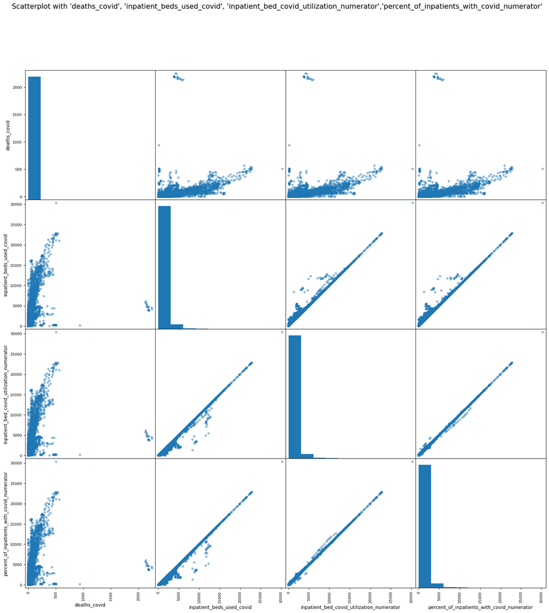

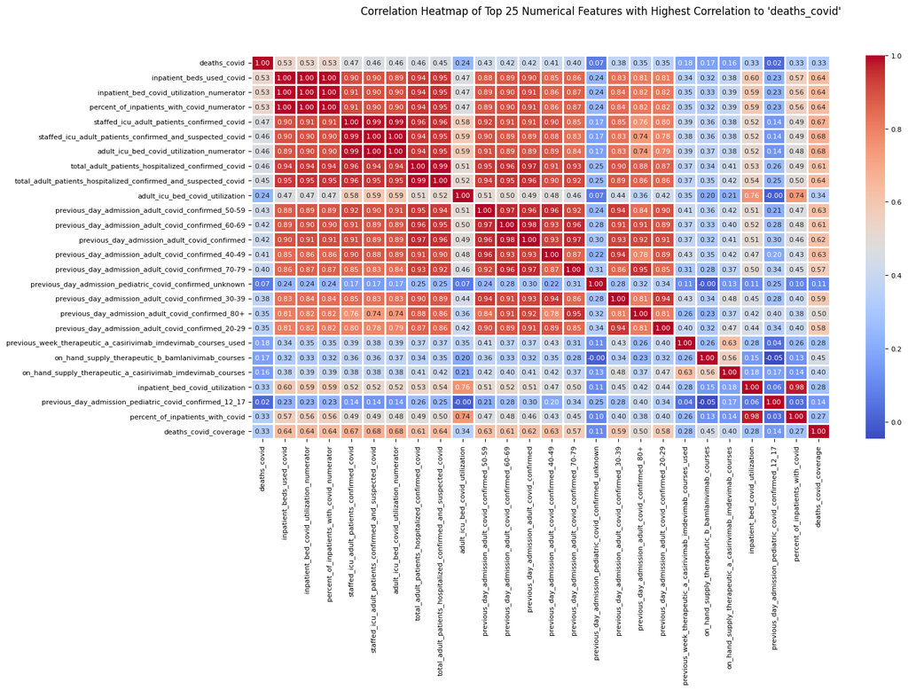

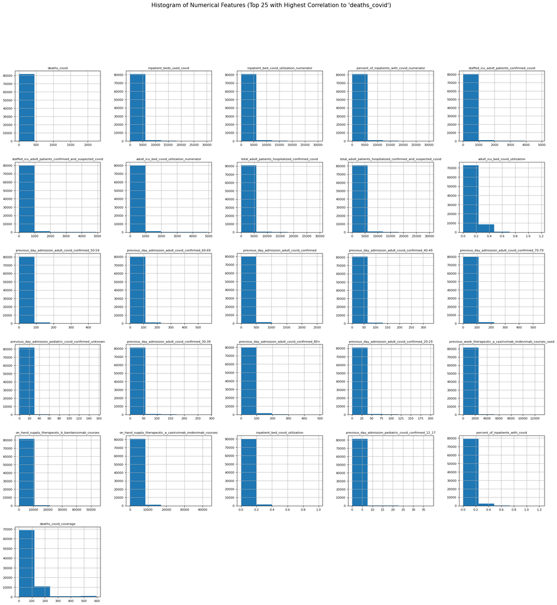

### III - Prepare the Data

```
---
'cov_cols' creation with 'deaths_covid' column removed since this is the TARGET/LABEL.
---
```

```
132
```

```
---
'cov_cols' length = 132 columns (due to removal of 'deaths_covid' column).
---
```

```
---
Creation of COVID_Data_Transformer class with use of BaseEstimator and TransformerMixin that allows the option for dropping the following features:

'inpatient_beds_used_covid'
'inpatient_bed_covid_utilization_numerator'
'percent_of_inpatients_with_covid_numerator'
---
```

```
Pipeline(steps=[('simpleimputer', SimpleImputer(strategy='median')),
                ('covid_data_transformer',
                 COVID_Data_Transformer(drop_features=False)),
                ('standardscaler', StandardScaler())])
```

```
---
'numeric_pipeline_with_features' -> numerical pipeline (with SimpleImputer, StandardScaler, COVID_Data_Transformer) WITH ALL the features
---
```

```
Pipeline(steps=[('simpleimputer', SimpleImputer(strategy='median')),
                ('covid_data_transformer', COVID_Data_Transformer()),
                ('standardscaler', StandardScaler())])
```

```
---
'numeric_pipeline_without_features' -> numerical pipeline (with SimpleImputer, StandardScaler, COVID_Data_Transformer) WITHOUT the following features:

'inpatient_beds_used_covid'
'inpatient_bed_covid_utilization_numerator'
'percent_of_inpatients_with_covid_numerator'
---
```

```
ColumnTransformer(transformers=[('num',
                                 Pipeline(steps=[('simpleimputer',
                                                  SimpleImputer(strategy='median')),
                                                 ('covid_data_transformer',
                                                  COVID_Data_Transformer(drop_features=False)),
                                                 ('standardscaler',
                                                  StandardScaler())]),
                                 ['critical_staffing_shortage_today_yes',
                                  'critical_staffing_shortage_today_no',
                                  'critical_staffing_shortage_today_not_reported',
                                  'critical...
                                  'staffed_icu_adult_patients_confirmed_and_suspected_covid',
                                  'staffed_icu_adult_patients_confirmed_and_suspected_covid_coverage',
                                  'staffed_icu_adult_patients_confirmed_covid',
                                  'staffed_icu_adult_patients_confirmed_covid_coverage',
                                  'total_adult_patients_hospitalized_confirmed_and_suspected_covid',
                                  'total_adult_patients_hospitalized_confirmed_and_suspected_covid_coverage', ...])])
```

```
---
'column_tranformer_with_features' -> ColumnTransformer WITH ALL the features
---
```

```
ColumnTransformer(transformers=[('num',
                                 Pipeline(steps=[('simpleimputer',
                                                  SimpleImputer(strategy='median')),
                                                 ('covid_data_transformer',
                                                  COVID_Data_Transformer()),
                                                 ('standardscaler',
                                                  StandardScaler())]),
                                 ['critical_staffing_shortage_today_yes',
                                  'critical_staffing_shortage_today_no',
                                  'critical_staffing_shortage_today_not_reported',
                                  'critical_staffing_shortage_...
                                  'staffed_icu_adult_patients_confirmed_and_suspected_covid',
                                  'staffed_icu_adult_patients_confirmed_and_suspected_covid_coverage',
                                  'staffed_icu_adult_patients_confirmed_covid',
                                  'staffed_icu_adult_patients_confirmed_covid_coverage',
                                  'total_adult_patients_hospitalized_confirmed_and_suspected_covid',
                                  'total_adult_patients_hospitalized_confirmed_and_suspected_covid_coverage', ...])])
```

```
---
'column_transformer_without_features' -> ColumnTransformer WITHOUT the following features:

'inpatient_beds_used_covid'
'inpatient_bed_covid_utilization_numerator'
'percent_of_inpatients_with_covid_numerator'
---
```

|  | critical_staffing_shortage_today_yes | critical_staffing_shortage_today_no | critical_staffing_shortage_today_not_reported | critical_staffing_shortage_anticipated_within_week_yes | critical_staffing_shortage_anticipated_within_week_no | critical_staffing_shortage_anticipated_within_week_not_reported | hospital_onset_covid | hospital_onset_covid_coverage | inpatient_beds | inpatient_beds_coverage | ... | previous_day_admission_pediatric_covid_confirmed_5_11 | previous_day_admission_pediatric_covid_confirmed_5_11_coverage | previous_day_admission_pediatric_covid_confirmed_unknown | previous_day_admission_pediatric_covid_confirmed_unknown_coverage | staffed_icu_pediatric_patients_confirmed_covid | staffed_icu_pediatric_patients_confirmed_covid_coverage | staffed_pediatric_icu_bed_occupancy | staffed_pediatric_icu_bed_occupancy_coverage | total_staffed_pediatric_icu_beds | total_staffed_pediatric_icu_beds_coverage |
| --- | --- | --- | --- | --- | --- | --- | --- | --- | --- | --- | --- | --- | --- | --- | --- | --- | --- | --- | --- | --- | --- |
| 27267 | 7 | 191 | 72 | 35 | 174 | 61 | 91.0 | 264 | 60469.0 | 270 | ... | 2.0 | 251 | 32.0 | 262 | 6.0 | 264 | 590.0 | 264 | 899.0 | 264 |
| 10831 | 46 | 170 | 6 | 49 | 167 | 6 | 12.0 | 216 | 14111.0 | 222 | ... | 0.0 | 0 | 0.0 | 0 | 0.0 | 0 | 2.0 | 4 | 11.0 | 4 |
| 8514 | 2 | 42 | 82 | 2 | 42 | 82 | 0.0 | 124 | 8064.0 | 126 | ... | 0.0 | 0 | 0.0 | 0 | 0.0 | 0 | 0.0 | 0 | 0.0 | 0 |
| 24511 | 2 | 166 | 11 | 9 | 159 | 11 | 265.0 | 170 | 44779.0 | 179 | ... | 2.0 | 155 | 1.0 | 170 | 11.0 | 170 | 363.0 | 170 | 523.0 | 170 |
| 56811 | 0 | 2 | 42 | 0 | 3 | 41 | 60.0 | 42 | 7342.0 | 44 | ... | 0.0 | 42 | 0.0 | 42 | 0.0 | 42 | 117.0 | 42 | 117.0 | 42 |

5 rows × 132 columns

```
---
First 5 rows of 'X_train'.
---
```

```
array([-5.96760838e-02,  2.41339295e+00,  3.51893898e-01,  1.16905151e+00,
        1.86347864e+00,  5.71163545e-01,  1.44723758e+00,  2.04829146e+00,
        3.20964372e+00,  1.84857967e+00,  3.34899005e+00,  1.85062120e+00,
        3.01312515e-01,  2.00274089e+00,  1.45493957e-01,  1.88140418e+00,
        9.41255382e-01,  2.05759582e+00,  5.45753632e+00,  1.88075618e+00,
        1.70068363e+00,  2.09515792e+00,  3.14028369e+00,  1.89054002e+00,
        1.04564644e-01,  2.08374361e+00,  4.51734670e-02,  1.88899314e+00,
        3.64604116e-01,  2.07597171e+00,  1.91492127e-01,  1.88397624e+00,
        1.35492306e-01,  2.07995719e+00,  2.26495727e-01,  1.87179733e+00,
        3.20391792e+00,  1.89274619e+00,  6.66301253e-01,  1.85527899e+00,
        3.35363179e+00,  3.21796976e+00, -6.87592565e-01,  2.03336759e+00,
        3.11139476e-01,  3.62971182e+00, -6.26490149e-01,  2.03473953e+00,
        3.12018409e-01,  3.46298473e+00, -5.77175365e-01,  2.09636472e+00,
        1.09036986e-01,  3.46654258e+00,  4.50100711e-01,  1.89351097e+00,
        3.14273346e+00,  3.20483413e+00,  0.00000000e+00,  5.21787761e-03,
        1.89532668e+00, -1.28811118e-01,  1.80127632e+00,  2.64908348e-01,
        1.80305124e+00,  2.80303228e-01,  1.80295896e+00,  1.51160265e-02,
        1.78028694e+00,  1.12350159e-01,  1.76805451e+00,  9.49916982e-02,
        1.77904242e+00,  2.45427505e-01,  1.79451404e+00,  7.60297585e-02,
        1.90327834e+00,  6.75767839e-01,  2.10400021e+00,  6.68971710e-01,
        1.98432405e+00,  1.20902158e+00,  1.98500743e+00,  8.77600531e-01,
        1.96171333e+00,  1.77403414e+00,  1.96108761e+00,  8.73216509e-01,
        1.93724886e+00,  7.41772090e-01,  1.94934817e+00,  8.62926290e-01,
        1.96713462e+00, -7.57128924e-02,  2.09686605e+00,  1.06655317e+00,
        1.56894857e+00, -3.23289920e-01,  2.20870089e+00,  2.89272761e+00,
        2.26525417e-01,  1.43910653e-01,  3.77317918e-01,  2.03416470e+00,
        9.42948924e-01,  2.03499976e+00, -5.99979900e-02,  1.41692022e+00,
       -7.97777945e-02,  1.36733412e+00,  5.58421851e-01, -9.40872960e-02,
        1.39590066e+00,  2.03436993e+00,  1.74009555e+00,  2.15376495e+00,
        2.08118212e+00,  2.15627852e+00,  5.08122259e-01,  2.64155558e+00,
        2.02787907e+00,  2.59594172e+00,  1.78172049e+00,  2.58347504e+00,
        1.00661626e+01,  2.62944170e+00,  8.99034918e-01,  2.57697982e+00,
        1.71412539e+00,  2.15925284e+00,  1.73918779e+00,  2.16040848e+00])
```

```
---
'X_train_transformed_with_features' -> .fit_transform() of 'X_train' using 'column_transformer_with_features'
---
```

```
array([-5.96760838e-02,  2.41339295e+00,  3.51893898e-01,  1.16905151e+00,
        1.86347864e+00,  5.71163545e-01,  1.44723758e+00,  2.04829146e+00,
        3.20964372e+00,  1.84857967e+00,  3.34899005e+00,  1.85062120e+00,
        2.00274089e+00,  1.45493957e-01,  1.88140418e+00,  9.41255382e-01,
        2.05759582e+00,  5.45753632e+00,  1.88075618e+00,  1.70068363e+00,
        2.09515792e+00,  3.14028369e+00,  1.89054002e+00,  1.04564644e-01,
        2.08374361e+00,  4.51734670e-02,  1.88899314e+00,  3.64604116e-01,
        2.07597171e+00,  1.91492127e-01,  1.88397624e+00,  1.35492306e-01,
        2.07995719e+00,  2.26495727e-01,  1.87179733e+00,  3.20391792e+00,
        1.89274619e+00,  6.66301253e-01,  1.85527899e+00,  3.35363179e+00,
        3.21796976e+00, -6.87592565e-01,  2.03336759e+00,  3.62971182e+00,
       -6.26490149e-01,  2.03473953e+00,  3.46298473e+00, -5.77175365e-01,
        2.09636472e+00,  1.09036986e-01,  3.46654258e+00,  4.50100711e-01,
        1.89351097e+00,  3.14273346e+00,  3.20483413e+00,  0.00000000e+00,
        5.21787761e-03,  1.89532668e+00, -1.28811118e-01,  1.80127632e+00,
        2.64908348e-01,  1.80305124e+00,  2.80303228e-01,  1.80295896e+00,
        1.51160265e-02,  1.78028694e+00,  1.12350159e-01,  1.76805451e+00,
        9.49916982e-02,  1.77904242e+00,  2.45427505e-01,  1.79451404e+00,
        7.60297585e-02,  1.90327834e+00,  6.75767839e-01,  2.10400021e+00,
        6.68971710e-01,  1.98432405e+00,  1.20902158e+00,  1.98500743e+00,
        8.77600531e-01,  1.96171333e+00,  1.77403414e+00,  1.96108761e+00,
        8.73216509e-01,  1.93724886e+00,  7.41772090e-01,  1.94934817e+00,
        8.62926290e-01,  1.96713462e+00, -7.57128924e-02,  2.09686605e+00,
        1.06655317e+00,  1.56894857e+00, -3.23289920e-01,  2.20870089e+00,
        2.89272761e+00,  2.26525417e-01,  1.43910653e-01,  3.77317918e-01,
        2.03416470e+00,  9.42948924e-01,  2.03499976e+00, -5.99979900e-02,
        1.41692022e+00, -7.97777945e-02,  1.36733412e+00,  5.58421851e-01,
       -9.40872960e-02,  1.39590066e+00,  2.03436993e+00,  1.74009555e+00,
        2.15376495e+00,  2.08118212e+00,  2.15627852e+00,  5.08122259e-01,
        2.64155558e+00,  2.02787907e+00,  2.59594172e+00,  1.78172049e+00,
        2.58347504e+00,  1.00661626e+01,  2.62944170e+00,  8.99034918e-01,
        2.57697982e+00,  1.71412539e+00,  2.15925284e+00,  1.73918779e+00,
        2.16040848e+00])
```

```
---
'X_train_transformed_without_features' -> .fit_transform() of 'X_train' using 'column_transformer_without_features'
---
```

### IV - Shortlist Promising Models

```
rmse_lin_reg_with_features: 31.209255192413945

rmse_lin_reg_without_features: 32.15335687083521
```

```
---
Use of cross_val_score ->

Linear Regression with features RMSE: 31.209255192413945

Linear Regression without features RMSE: 32.15335687083521

*features excluded for 'without features':

'inpatient_beds_used_covid'
'inpatient_bed_covid_utilization_numerator'
'percent_of_inpatients_with_covid_numerator'
---
```

```
rmse_svm_with_features: 35.204359597599925

rmse_svm_without_features: 35.45478597938301
```

```
---
Use of cross_val_score ->

SVM Regression with features RMSE: 35.204359597599925

SVM Regression without features RMSE: 35.45478597938301

*features excluded for 'without features':

'inpatient_beds_used_covid'
'inpatient_bed_covid_utilization_numerator'
'percent_of_inpatients_with_covid_numerator'
---
```

```
rmse_lasso_with_features: 31.990149647894203

rmse_lasso_without_features 33.09643057612391
```

```
---
Use of cross_val_score ->

Lasso Regression with features RMSE: 31.990149647894203

Lasso Regression without features RMSE: 33.09643057612391

*features excluded for 'without features':

'inpatient_beds_used_covid'
'inpatient_bed_covid_utilization_numerator'
'percent_of_inpatients_with_covid_numerator'
---
```

### V - Fine-Tune the System

```
{'fit_intercept': [True, False], 'n_jobs': [None, -1]}
```

```
---
Use of param_grid.
---
```

```
best_params_with_features: {'fit_intercept': True, 'n_jobs': None}
best_score_with_features: 0.37902582911177357

best_params_without_features: {'fit_intercept': True, 'n_jobs': None}
best_score_without_features: 0.34096848532935065
```

```
---
Use of GridSearchCV above for Linear Regression.

*features excluded for 'without features':

'inpatient_beds_used_covid'
'inpatient_bed_covid_utilization_numerator'
'percent_of_inpatients_with_covid_numerator'
---
```

```
array([ 9.35703575e-01,  2.25923687e-01, -6.13279298e-01,  5.40213105e-01,
       -4.48542136e-02, -3.88614968e-01,  2.65688515e-01,  2.20454625e-03,
       -9.66799661e-02, -1.47869258e-01, -5.94010617e-02, -1.47436924e-01,
        1.22709543e+00, -1.91247227e-02,  1.40356340e+00, -8.38067393e-02,
        7.79465200e-02,  2.66621719e-02,  1.21416706e+00, -7.37244123e-02,
       -2.94747075e-01,  6.91246773e-02,  7.60089907e-02, -7.58882090e-02,
        9.02949494e-01,  5.85799051e-02,  9.69761382e-01, -7.84015036e-02,
        1.32731710e+00,  5.09265991e-02,  1.41434471e+00, -8.43984573e-02,
        9.02665295e-01,  5.56103603e-02,  1.55531999e+00, -7.90131336e-02,
       -1.94593305e-02, -7.47666592e-02,  5.54097011e-01, -1.43317461e-01,
       -5.66168277e-02, -9.38203500e-02,  3.15688395e+00, -6.00743032e-03,
        1.24687522e+00,  3.84640302e-02,  3.35359509e+00, -5.34133822e-03,
        1.24867834e+00, -3.80400587e-04,  2.28989056e+00,  6.63045248e-02,
        9.11695273e-01,  6.65188543e-02,  7.59646667e-01, -7.31632486e-02,
        7.73384730e-02, -1.87433118e-02,  0.00000000e+00,  2.38232700e-02,
       -1.13677003e-01,  1.07457347e+00, -1.10973775e-01,  7.45745040e-01,
       -1.10565469e-01,  1.50177939e+00, -8.87664912e-02,  1.20573225e+00,
       -1.11337621e-01,  1.70942837e+00, -1.01270732e-01,  2.01231386e+00,
       -1.23374489e-01,  1.05671628e+00, -1.09425139e-01, -1.01478914e-01,
       -1.21581466e-01, -2.97366431e-01,  3.72789804e-02, -1.43229644e-01,
        1.26476687e-02, -1.45900316e-01,  2.43223819e-02, -5.49971559e-02,
        1.35386968e-02, -1.25074785e-01,  2.36303885e-02,  1.19639355e-01,
       -3.95143210e-05,  6.38861558e-01,  1.18615079e-02,  1.76432101e-01,
       -7.73462940e-03, -2.12386236e-01,  8.80417906e-03, -8.36030585e-03,
        1.07492770e-01,  5.59852015e-01,  6.48172450e-01, -5.98656768e-03,
       -2.87456824e-02,  4.13803693e-02, -2.79933522e-01, -9.18505389e-03,
       -2.35795835e-01, -8.87876282e-03, -5.99979900e-02,  2.63810263e-01,
       -7.97777945e-02,  2.42072509e-01, -1.71931674e-01,  6.47510772e-02,
        2.26475533e-01, -9.07660095e-03, -3.73070327e-01, -3.53661788e-01,
       -3.86580399e-01, -3.73467186e-01, -3.86716090e-01, -4.76996887e-02,
        4.92089383e-01, -2.42160523e-02, -2.92508488e-01, -2.62577292e-02,
        3.07397704e+00,  2.01265515e-01,  6.92083304e-01, -1.09377723e-01,
       -4.60020940e-01, -3.62349528e-01, -4.67874797e-01, -3.60631449e-01])
```

```
---
'X_test_transformed_with_features' -> .transform() of 'X_test' using 'column_transformer_with_features'
---
```

```
array([ 9.35703575e-01,  2.25923687e-01, -6.13279298e-01,  5.40213105e-01,
       -4.48542136e-02, -3.88614968e-01,  2.65688515e-01,  2.20454625e-03,
       -9.66799661e-02, -1.47869258e-01, -5.94010617e-02, -1.47436924e-01,
       -1.91247227e-02,  1.40356340e+00, -8.38067393e-02,  7.79465200e-02,
        2.66621719e-02,  1.21416706e+00, -7.37244123e-02, -2.94747075e-01,
        6.91246773e-02,  7.60089907e-02, -7.58882090e-02,  9.02949494e-01,
        5.85799051e-02,  9.69761382e-01, -7.84015036e-02,  1.32731710e+00,
        5.09265991e-02,  1.41434471e+00, -8.43984573e-02,  9.02665295e-01,
        5.56103603e-02,  1.55531999e+00, -7.90131336e-02, -1.94593305e-02,
       -7.47666592e-02,  5.54097011e-01, -1.43317461e-01, -5.66168277e-02,
       -9.38203500e-02,  3.15688395e+00, -6.00743032e-03,  3.84640302e-02,
        3.35359509e+00, -5.34133822e-03, -3.80400587e-04,  2.28989056e+00,
        6.63045248e-02,  9.11695273e-01,  6.65188543e-02,  7.59646667e-01,
       -7.31632486e-02,  7.73384730e-02, -1.87433118e-02,  0.00000000e+00,
        2.38232700e-02, -1.13677003e-01,  1.07457347e+00, -1.10973775e-01,
        7.45745040e-01, -1.10565469e-01,  1.50177939e+00, -8.87664912e-02,
        1.20573225e+00, -1.11337621e-01,  1.70942837e+00, -1.01270732e-01,
        2.01231386e+00, -1.23374489e-01,  1.05671628e+00, -1.09425139e-01,
       -1.01478914e-01, -1.21581466e-01, -2.97366431e-01,  3.72789804e-02,
       -1.43229644e-01,  1.26476687e-02, -1.45900316e-01,  2.43223819e-02,
       -5.49971559e-02,  1.35386968e-02, -1.25074785e-01,  2.36303885e-02,
        1.19639355e-01, -3.95143210e-05,  6.38861558e-01,  1.18615079e-02,
        1.76432101e-01, -7.73462940e-03, -2.12386236e-01,  8.80417906e-03,
       -8.36030585e-03,  1.07492770e-01,  5.59852015e-01,  6.48172450e-01,
       -5.98656768e-03, -2.87456824e-02,  4.13803693e-02, -2.79933522e-01,
       -9.18505389e-03, -2.35795835e-01, -8.87876282e-03, -5.99979900e-02,
        2.63810263e-01, -7.97777945e-02,  2.42072509e-01, -1.71931674e-01,
        6.47510772e-02,  2.26475533e-01, -9.07660095e-03, -3.73070327e-01,
       -3.53661788e-01, -3.86580399e-01, -3.73467186e-01, -3.86716090e-01,
       -4.76996887e-02,  4.92089383e-01, -2.42160523e-02, -2.92508488e-01,
       -2.62577292e-02,  3.07397704e+00,  2.01265515e-01,  6.92083304e-01,
       -1.09377723e-01, -4.60020940e-01, -3.62349528e-01, -4.67874797e-01,
       -3.60631449e-01])
```

```
---
'X_test_transformed_without_features' -> .transform() of 'X-test' using 'column_transformer_without_features'
---
```

```
LinearRegression()
```

```
---
Linear Regression .fit() using 'X_train_transformed_with_features' and 'y_train'
---
```

```
array([31.37102116,  5.5785944 ,  2.72733994, ...,  1.84073981,
       16.56264882,  6.22901791])
```

```
---
'final_predictions_rmse_with_features' -> Linear Regression .predict() using `X_test_transformed_with_features`
---
```

```
35.28261942520221
```

```
---
'final_rmse_lin_reg_with_features' -> mean_squared_error using 'y_test' and 'final_predictions_rmse_with_features'
---
```

```
0.31276809130068284
```

```
---
'r2_lin_reg_with_features' -> Linear Regression .score() using 'X_test_transformed_with_features' and 'y_test'
---
```

```
LinearRegression()
```

```
---
Linear Regression .fit() using 'X_train_transformed_without_features' and 'y_train'
---
```

```python
final_predictions_rmse_without_features
```

```
array([40.81107884, 11.73828483,  1.27652758, ...,  2.00487829,
       11.84537313, 14.33409067])
```

```
---
'final_predictions_rmse_without_features' -> Linear Regression .predict() using `X_test_transformed_without_features`
---
```

```python
final_rmse_lin_reg_without_features
```

```
36.29493484368097
```

```
---
'final_rmse_lin_reg_without_features' -> mean_squared_error using 'y_test' and 'final_predictions_rmse_without_features'
---
```

```python
r2_lin_reg_without_features = lin_reg.score(X_test_transformed_without_features, y_test)

r2_lin_reg_without_features
```

```
0.2727667658494083
```

```
---
'r2_lin_reg_without_features' -> Linear Regression .score() using 'X_test_transformed_without_features' and 'y_test'
---
```

### Summary

Between Linear Regression, Support Vector Machine (SVM) Regression, and Lasso Regression, Linear Regression had the best (lowest) RMSE (Root Mean Squared Error) for both the model that includes and does not include specific features ('inpatient_beds_used_covid', 'inpatient_bed_covid_utilization_numerator', and 'percent_of_inpatients_with_covid_numerator').

--

Linear Regression with features (initial) RMSE: 31.209255192413945

Linear Regression without features (initial) RMSE: 32.15335687083521

--

SVM Regression with features RMSE: 35.204359597599925

SVM Regression without features RMSE: 35.45478597938301

--

Lasso Regression with features RMSE: 31.990149647894203

Lasso Regression without features RMSE: 33.09643057612391

--

However, the Linear Regression with features yielded a final RMSE of 35.28261942520221 and a poor R-squared value of 0.31276809130068284, indicating the model was only able to make 31.3% accurate predictions and explain the variability with the features/attributes utilized. The increase from initial to final RMSE is minimal and most likely due to the model's generalization to new data.

Linear Regression with features (final) RMSE: 35.28261942520221

Linear Regression with features R-squared: 0.31276809130068284

And the Linear Regression without features yielded a final RMSE of 36.29493484368097 and a poor R-squared value of 0.2727667658494083, indicating the model was only able to make 27.3% accurate predictions and explain the variability with the features/attributes utilized. The increase in from initial to final RMSE is minimal and most likely due to the model's generalization to new data.

Linear Regression without features (final) RMSE: 36.29493484368097

Linear Regression without features R-squared: 0.2727667658494083

The performance of these models are too low and would need further improvement before deployment, such as improving the selection of features, different method of handling missing data, utilizing other algorithms, etc.